# Predict Bike Sharing Demand with AutoGluon Template

## Project: Predict Bike Sharing Demand with AutoGluon

This notebook is a template with each step that you need to complete for the project.

Please fill in your code where there are explicit `?` markers in the notebook. You are welcome to add more cells and code as you see fit.

Once you have completed all the code implementations, please export your notebook as a HTML file so the reviews can view your code. Make sure you have all outputs correctly outputted.

`File-> Export Notebook As... -> Export Notebook as HTML`

There is a writeup to complete as well after all code implememtation is done. Please answer all questions and attach the necessary tables and charts. You can complete the writeup in either markdown or PDF.

Completing the code template and writeup template will cover all of the rubric points for this project.

The rubric contains "Stand Out Suggestions" for enhancing the project beyond the minimum requirements. The stand out suggestions are optional. If you decide to pursue the "stand out suggestions", you can include the code in this notebook and also discuss the results in the writeup file.

## Step 1: Create an account with Kaggle

### Create Kaggle Account and download API key

Below is example of steps to get the API username and key. Each student will have their own username and key.

1. Open account settings.

2. Scroll down to API and click Create New API Token.

3. Open up `kaggle.json` and use the username and key.


## Step 2: Download the Kaggle dataset using the kaggle python library

### Open up Sagemaker Studio and use starter template

1. Notebook should be using a `ml.t3.medium` instance (2 vCPU + 4 GiB)
2. Notebook should be using kernal: `Python 3 (MXNet 1.8 Python 3.7 CPU Optimized)`

### Install packages

```python
!pip install -U pip
!pip install -U setuptools wheel
!pip install -U "mxnet<2.0.0" bokeh==2.0.1
!pip install autogluon --no-cache-dir

!pip install kaggle --upgrade
!pip install bokeh==2.0.1
!pip install seaborn
# Without --no-cache-dir, smaller aws instances may have trouble installing
```

### Setup Kaggle API Key

```python
# create the .kaggle directory and an empty kaggle.json file
!mkdir -p .kaggle
!touch .kaggle/kaggle.json
!chmod 600 .kaggle/kaggle.json
```

```python
# Fill in your user name and key from creating the kaggle account and API token file
import json
kaggle_username = "FILL_IN_USERNAME"
kaggle_key = "FILL_IN_KEY"

# Save API token the kaggle.json file
with open(".kaggle/kaggle.json", "w") as f:
    f.write(json.dumps({"username": kaggle_username, "key": kaggle_key}))
```

### Download and explore dataset

### Go to the bike sharing demand competition and agree to the terms

```python
# Download the dataset, it will be in a .zip file so you'll need to unzip it as well.
!kaggle competitions download -c bike-sharing-demand

# If you already downloaded it you can use the -o command to overwrite the file
!unzip -o bike-sharing-demand.zip
```

```
bike-sharing-demand.zip: Skipping, found more recently modified local copy (use --force to force download)
Archive:  bike-sharing-demand.zip
  inflating: sampleSubmission.csv
  inflating: test.csv
  inflating: train.csv
```

```python
import matplotlib.pyplot as plt
import numpy as np
import pandas as pd
import seaborn as sns

from autogluon.tabular import TabularPredictor
```

```python
# Create the train dataset in pandas by reading the csv
# Set the parsing of the datetime column
# so you can use some of the `dt` features in pandas later
train = pd.read_csv("train.csv", parse_dates=["datetime"])
train.head()
```

|  | datetime | season | holiday | workingday | weather | temp | atemp | humidity | windspeed | casual | registered | count |
| --- | --- | --- | --- | --- | --- | --- | --- | --- | --- | --- | --- | --- |
| 0 | 2011-01-01 00:00:00 | 1 | 0 | 0 | 1 | 9.84 | 14.395 | 81 | 0.0 | 3 | 13 | 16 |
| 1 | 2011-01-01 01:00:00 | 1 | 0 | 0 | 1 | 9.02 | 13.635 | 80 | 0.0 | 8 | 32 | 40 |
| 2 | 2011-01-01 02:00:00 | 1 | 0 | 0 | 1 | 9.02 | 13.635 | 80 | 0.0 | 5 | 27 | 32 |
| 3 | 2011-01-01 03:00:00 | 1 | 0 | 0 | 1 | 9.84 | 14.395 | 75 | 0.0 | 3 | 10 | 13 |
| 4 | 2011-01-01 04:00:00 | 1 | 0 | 0 | 1 | 9.84 | 14.395 | 75 | 0.0 | 0 | 1 | 1 |

#### Plot the Bike Sharing Demand Time Series Data

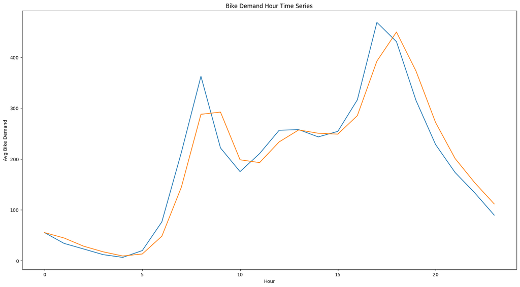

```python
# Set the figure size to 19, 10
plt.figure(figsize=(19, 10))


def plot_time_series_data(
    df: pd.DataFrame,
    time_series_type: str = "month",
    use_avg: bool = True,
    show_rolling_mean: bool = False,
    title: str = ""
) -> None:
    """Plot the time series data

    """

    def get_date_value(df: pd.DataFrame, time_series_type: str):
        """Return date value for the data
        """
        if time_series_type == "hour":
            return df["datetime"].dt.hour, "Hour"
        if time_series_type == "weekday":
            return df["datetime"].dt.weekday, "Weekday"
        if time_series_type == "month":
            return df["datetime"].dt.month, "Month"
        if time_series_type == "year":
            return df["datetime"].dt.year, "Year"
        return df["datetime"].dt.date, "Date"


    df["date"], x_label = get_date_value(df, time_series_type)
    y_label = f"{'Avg' if use_avg else 'Total'} {title}"

    # Aggregate the data based on the timeframe specified
    # and the agg method
    df = df.groupby("date").agg(
            agg_value=pd.NamedAgg(
                column="count",
                aggfunc="mean" if use_avg else "sum"
            )
    )


    # Label the axes and setting
    plt.xlabel(x_label)
    plt.ylabel(y_label)

    plt.title(f"{title} {x_label} Time Series")


    # Plot the graph(s)
    plt.plot(df["agg_value"])

    if show_rolling_mean:
        df_rolled = df.rolling(window=2,min_periods=1)
        df_rolled = df_rolled.mean() if use_avg else df_rolled.sum()
        plt.plot(df_rolled["agg_value"])


# Plot the data in hourly, daily, monthly, and yearly timeframes
plot_time_series_data(train, "hour", use_avg=True, show_rolling_mean=True, title="Bike Demand")
# plot_time_series_data(train, "weekday", use_avg=True, show_rolling_mean=True, title="Bike Demand")
# plot_time_series_data(train, "month", use_avg=True, show_rolling_mean=True, title="Bike Demand")
# plot_time_series_data(train, "year", use_avg=True, show_rolling_mean=True, title="Bike Demand")
```

```python
# Simple output of the train dataset to view some of the min/max/varition of the dataset features.
train.describe()
train.drop(["date"], axis=1, inplace=True)
```

```python
# Create the test pandas dataframe in pandas by reading the csv, remember to parse the datetime!
test = pd.read_csv("test.csv", parse_dates=["datetime"])
test.head()
```

|  | datetime | season | holiday | workingday | weather | temp | atemp | humidity | windspeed |
| --- | --- | --- | --- | --- | --- | --- | --- | --- | --- |
| 0 | 2011-01-20 00:00:00 | 1 | 0 | 1 | 1 | 10.66 | 11.365 | 56 | 26.0027 |
| 1 | 2011-01-20 01:00:00 | 1 | 0 | 1 | 1 | 10.66 | 13.635 | 56 | 0.0000 |
| 2 | 2011-01-20 02:00:00 | 1 | 0 | 1 | 1 | 10.66 | 13.635 | 56 | 0.0000 |
| 3 | 2011-01-20 03:00:00 | 1 | 0 | 1 | 1 | 10.66 | 12.880 | 56 | 11.0014 |
| 4 | 2011-01-20 04:00:00 | 1 | 0 | 1 | 1 | 10.66 | 12.880 | 56 | 11.0014 |

```python
# Same thing as train and test dataset
submission = pd.read_csv("sampleSubmission.csv", parse_dates=["datetime"])
submission.head()
```

|  | datetime | count |
| --- | --- | --- |
| 0 | 2011-01-20 00:00:00 | 0 |
| 1 | 2011-01-20 01:00:00 | 0 |
| 2 | 2011-01-20 02:00:00 | 0 |
| 3 | 2011-01-20 03:00:00 | 0 |
| 4 | 2011-01-20 04:00:00 | 0 |

## Step 3: Train a model using AutoGluon’s Tabular Prediction

Requirements:

```python
# Set the label variable
LABEL = "count"
MODEL_EVAL_METRIC = "root_mean_squared_error"
MODEL_PREDICTION_TIME_LIMIT = 120 #seconds
MODEL_PREDICTION_PRESET = ("best_quality")
DATA_COLS_TO_IGNORE = ("casual", "registered")
```

```python
# Drop columns not present in the test data
train_data = train.loc[:, ~train.columns.isin(DATA_COLS_TO_IGNORE)]
```

```python
# Create a dict mapping for the predictor option values
# to be used later on in the notebook
predictor_options = {
    "eval_metric": MODEL_EVAL_METRIC,
    "label": LABEL,
    "presets": MODEL_PREDICTION_PRESET,
    "time_limit": MODEL_PREDICTION_TIME_LIMIT,
}
```

```python
# Create the TabularPredictor and fit it with the training data
# Here, default values are used
predictor = TabularPredictor(
    label=predictor_options["label"],
    eval_metric=predictor_options["eval_metric"]
).fit(
    train_data=train_data,
    time_limit=predictor_options["time_limit"],
    presets=predictor_options["presets"]
)
```

[output not shown]

[output cut: 53 more lines]

```
	Fitting 8 child models (S1F1 - S1F8) | Fitting with ParallelLocalFoldFittingStrategy
	-54.9889	 = Validation score   (-root_mean_squared_error)
	4.29s	 = Training   runtime
	0.35s	 = Validation runtime
Fitting model: RandomForestMSE_BAG_L2 ... Training model for up to 5.9s of the 5.89s of remaining time.
	-53.4033	 = Validation score   (-root_mean_squared_error)
	8.52s	 = Training   runtime
	0.46s	 = Validation runtime
Completed 1/20 k-fold bagging repeats ...
Fitting model: WeightedEnsemble_L3 ... Training model for up to 119.9s of the -3.57s of remaining time.
	-53.0627	 = Validation score   (-root_mean_squared_error)
	0.14s	 = Training   runtime
	0.0s	 = Validation runtime
AutoGluon training complete, total runtime = 123.73s ... Best model: "WeightedEnsemble_L3"
TabularPredictor saved. To load, use: predictor = TabularPredictor.load("AutogluonModels/ag-20230126_220356/")
```

### Review AutoGluon's training run with ranking of models that did the best.

```python
predictor.fit_summary()
```

```
*** Summary of fit() ***
Estimated performance of each model:
                     model   score_val  pred_time_val   fit_time  pred_time_val_marginal  fit_time_marginal  stack_level  can_infer  fit_order
0      WeightedEnsemble_L3  -53.062678      22.074831  87.650311                0.000475           0.144813            3       True         12
1   RandomForestMSE_BAG_L2  -53.403286      14.078619  66.702703                0.459357           8.522999            2       True         11
2          LightGBM_BAG_L2  -54.988887      13.970415  62.471755                0.351153           4.292051            2       True         10
3        LightGBMXT_BAG_L2  -60.087147      21.263846  74.690450                7.644583          16.510746            2       True          9
4    KNeighborsDist_BAG_L1  -84.125061       0.026441   0.029280                0.026441           0.029280            1       True          2
5      WeightedEnsemble_L2  -84.125061       0.026932   0.298327                0.000491           0.269047            2       True          8
6    KNeighborsUnif_BAG_L1 -101.546199       0.023068   0.033537                0.023068           0.033537            1       True          1
7   RandomForestMSE_BAG_L1 -116.548359       0.417001   3.766313                0.417001           3.766313            1       True          5
8     ExtraTreesMSE_BAG_L1 -124.600676       0.405968   2.636169                0.405968           2.636169            1       True          7
9          CatBoost_BAG_L1 -130.853786       0.123297  28.446325                0.123297          28.446325            1       True          6
10         LightGBM_BAG_L1 -131.054162       1.586252   5.571735                1.586252           5.571735            1       True          4
11       LightGBMXT_BAG_L1 -131.460909      11.037235  17.696345               11.037235          17.696345            1       True          3
Number of models trained: 12
Types of models trained:
{'StackerEnsembleModel_RF', 'StackerEnsembleModel_LGB', 'WeightedEnsembleModel', 'StackerEnsembleModel_CatBoost', 'StackerEnsembleModel_KNN', 'StackerEnsembleModel_XT'}
Bagging used: True  (with 8 folds)
Multi-layer stack-ensembling used: True  (with 3 levels)
Feature Metadata (Processed):
(raw dtype, special dtypes):
('float', [])                : 3 | ['temp', 'atemp', 'windspeed']
('int', [])                  : 3 | ['season', 'weather', 'humidity']
('int', ['bool'])            : 2 | ['holiday', 'workingday']
('int', ['datetime_as_int']) : 5 | ['datetime', 'datetime.year', 'datetime.month', 'datetime.day', 'datetime.dayofweek']
*** End of fit() summary ***
```

[output not shown]

[output cut: 102 more lines]

[output not shown]

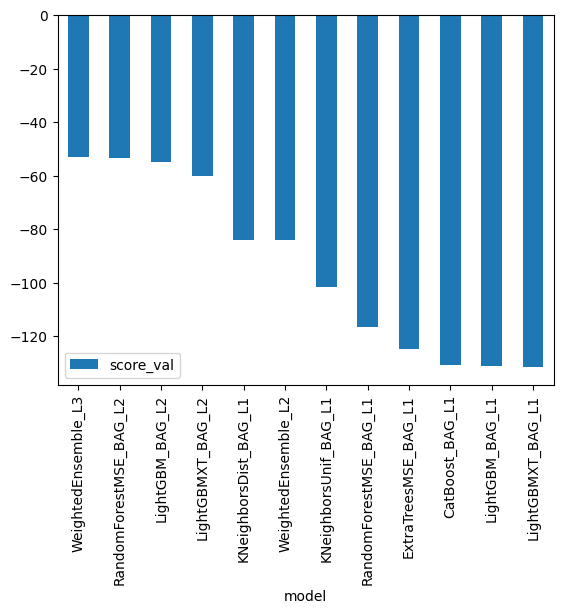

```python
# Output the model's `score_val` in a bar chart to compare performance
predictor.leaderboard(silent=True).plot(kind="bar", x="model", y="score_val")
```

### Create predictions from test dataset

```python
predictions = predictor.predict(test)
predictions.head()
```

```
0    23.381523
1    42.150497
2    46.101196
3    48.981674
4    51.890598
Name: count, dtype: float32
```

#### NOTE: Kaggle will reject the submission if we don't set everything to be > 0.

```python
# Describe the `predictions` series to see if there are any negative values
predictions.describe()

# How many negative values do we have?
print(f"{len(predictions[predictions < 0])} negative values present")

# Set them to zero
predictions[predictions < 0] = 0
```

```
0 negative values present
```

### Set predictions to submission dataframe, save, and submit

```python
submission["count"] = predictions
submission.to_csv("submission.csv", index=False)
```

```python
!kaggle competitions submit -c bike-sharing-demand -f submission.csv -m "Raw submission #4"
```

```
Successfully submitted to Bike Sharing Demand
```

#### View submission via the command line or in the web browser under the competition's page - `My Submissions`

```python
!kaggle competitions submissions -c bike-sharing-demand | tail -n +1 | head -n 5
```

```
fileName                     date                 description                          status    publicScore  privateScore
---------------------------  -------------------  -----------------------------------  --------  -----------  ------------
submission.csv               2023-01-26 22:06:20  Raw submission #4                    complete  1.80891      1.80891
submission_new_hpo.csv       2023-01-26 21:47:34  new features hpo iii                 complete  0.48829      0.48829
submission_new_features.csv  2023-01-26 21:45:16  new features test iv                 complete  0.71067      0.71067
```

#### Initial score of `1.80891`

## Step 4: Exploratory Data Analysis and Creating an additional feature

- Any additional feature will do, but a great suggestion would be to separate out the datetime into hour, day, or month parts.

```
array([[<AxesSubplot: title={'center': 'datetime'}>,
        <AxesSubplot: title={'center': 'season'}>,
        <AxesSubplot: title={'center': 'holiday'}>],
       [<AxesSubplot: title={'center': 'workingday'}>,
        <AxesSubplot: title={'center': 'weather'}>,
        <AxesSubplot: title={'center': 'temp'}>],
       [<AxesSubplot: title={'center': 'atemp'}>,
        <AxesSubplot: title={'center': 'humidity'}>,
        <AxesSubplot: title={'center': 'windspeed'}>],
       [<AxesSubplot: title={'center': 'casual'}>,
        <AxesSubplot: title={'center': 'registered'}>,
        <AxesSubplot: title={'center': 'count'}>],
       [<AxesSubplot: >, <AxesSubplot: >, <AxesSubplot: >],
       [<AxesSubplot: >, <AxesSubplot: >, <AxesSubplot: >],
       [<AxesSubplot: >, <AxesSubplot: >, <AxesSubplot: >]], dtype=object)
```

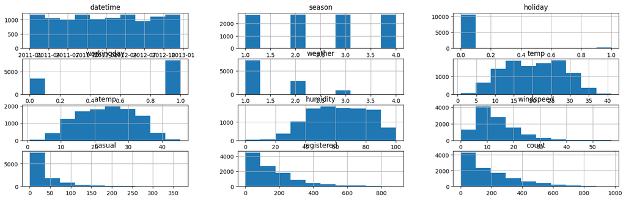

```python
# Create a histogram of all features to show the distribution of each one relative to the data.
# This is part of the exploritory data analysis
train.hist(figsize=(19,10), layout=(7,3),)
```

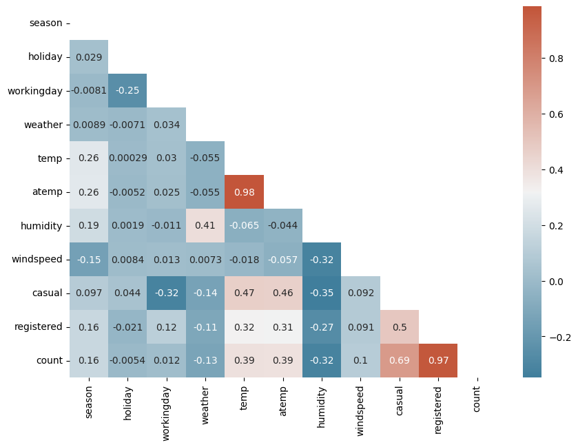

```python
# Create a heatmap to show the correlation between the different features

# Correlation between different variables
corr = train.corr()

# Set up the matplotlib plot configuration
f, ax = plt.subplots(figsize=(10, 7))

# Generate a mask for upper traingle
mask = np.triu(np.ones_like(corr, dtype=bool))

# Configure a custom diverging colormap
cmap = sns.diverging_palette(230, 20, as_cmap=True)

# Draw the heatmap
sns.heatmap(corr, annot=True, mask=mask, cmap=cmap)
```

```python
# Functions to help in generating new features

def get_wind_category(windspeed: int) -> str:
    """Return the category for windspeed
    """
    if windspeed <= 15:
        return "mild"
    return "windy"


def get_feels_like_temp_category(atemp: int) -> str:
    """Return the category for reported temp
    """
    if atemp <= 10:
        return "cold"
    if atemp > 10 and atemp <= 25:
        return "mild"
    if atemp > 25 and atemp <= 35:
        return "hot"
    return "very_hot"


def get_humidity_category(humidity: int) -> str:
    """Return the category for humidity
    """
    if humidity <= 40:
        return "not_humid"
    if humidity > 40 and humidity <= 80:
        return "humid"
    return "very_humid"


def one_hot_encode_feature(df, column, category_func, prefix):
    """One hot encode categorical features
    """

    # First get the category using the defined function
    df[prefix] = df[column].apply(category_func)

    # Then update it to category type
    df[prefix] = df[prefix].astype("category")

    # Generate the one hot encoded values
    one_hot_df = pd.get_dummies(df[prefix], prefix=prefix)

    # Add the one hot encoded values to the df
    df[one_hot_df.columns.tolist()] = one_hot_df

    return df
```

```python
# Create new features from the data

def generate_new_date_features(df: pd.DataFrame):
    """Generate new featues using existing date
    """
    # 'Hour' feature using the date component
    # extract only the hour part
    df["hour"] = df["datetime"].dt.hour

    # 'Day' feature using the date component
    # extract only the hour part
    df["day"] = df["datetime"].dt.weekday

    # 'Month' feature using the date component
    # extract only the hour part
    df["month"] = df["datetime"].dt.month

    return df


def generate_new_category_features(df: pd.DataFrame):
    """Generate new features for categorical data
    """
    df = one_hot_encode_feature(df, "humidity", get_humidity_category, "level")
    df = one_hot_encode_feature(df, "atemp", get_feels_like_temp_category, "a_temp")
    df = one_hot_encode_feature(df, "windspeed", get_wind_category, "wind_speed")

    return df
```

```python
train = generate_new_date_features(train)
train = generate_new_category_features(train)

train.head()
```

|  | datetime | season | holiday | workingday | weather | temp | atemp | humidity | windspeed | casual | ... | level_not_humid | level_very_humid | a_temp | a_temp_cold | a_temp_hot | a_temp_mild | a_temp_very_hot | wind_speed | wind_speed_mild | wind_speed_windy |
| --- | --- | --- | --- | --- | --- | --- | --- | --- | --- | --- | --- | --- | --- | --- | --- | --- | --- | --- | --- | --- | --- |
| 0 | 2011-01-01 00:00:00 | 1 | 0 | 0 | 1 | 9.84 | 14.395 | 81 | 0.0 | 3 | ... | 0 | 1 | mild | 0 | 0 | 1 | 0 | mild | 1 | 0 |
| 1 | 2011-01-01 01:00:00 | 1 | 0 | 0 | 1 | 9.02 | 13.635 | 80 | 0.0 | 8 | ... | 0 | 0 | mild | 0 | 0 | 1 | 0 | mild | 1 | 0 |
| 2 | 2011-01-01 02:00:00 | 1 | 0 | 0 | 1 | 9.02 | 13.635 | 80 | 0.0 | 5 | ... | 0 | 0 | mild | 0 | 0 | 1 | 0 | mild | 1 | 0 |
| 3 | 2011-01-01 03:00:00 | 1 | 0 | 0 | 1 | 9.84 | 14.395 | 75 | 0.0 | 3 | ... | 0 | 0 | mild | 0 | 0 | 1 | 0 | mild | 1 | 0 |
| 4 | 2011-01-01 04:00:00 | 1 | 0 | 0 | 1 | 9.84 | 14.395 | 75 | 0.0 | 0 | ... | 0 | 0 | mild | 0 | 0 | 1 | 0 | mild | 1 | 0 |

5 rows × 27 columns

```python
# Generate the same new features for the test dataset
test = generate_new_date_features(test)
test = generate_new_category_features(test)

test.head()
```

|  | datetime | season | holiday | workingday | weather | temp | atemp | humidity | windspeed | hour | ... | level_not_humid | level_very_humid | a_temp | a_temp_cold | a_temp_hot | a_temp_mild | a_temp_very_hot | wind_speed | wind_speed_mild | wind_speed_windy |
| --- | --- | --- | --- | --- | --- | --- | --- | --- | --- | --- | --- | --- | --- | --- | --- | --- | --- | --- | --- | --- | --- |
| 0 | 2011-01-20 00:00:00 | 1 | 0 | 1 | 1 | 10.66 | 11.365 | 56 | 26.0027 | 0 | ... | 0 | 0 | mild | 0 | 0 | 1 | 0 | windy | 0 | 1 |
| 1 | 2011-01-20 01:00:00 | 1 | 0 | 1 | 1 | 10.66 | 13.635 | 56 | 0.0000 | 1 | ... | 0 | 0 | mild | 0 | 0 | 1 | 0 | mild | 1 | 0 |
| 2 | 2011-01-20 02:00:00 | 1 | 0 | 1 | 1 | 10.66 | 13.635 | 56 | 0.0000 | 2 | ... | 0 | 0 | mild | 0 | 0 | 1 | 0 | mild | 1 | 0 |
| 3 | 2011-01-20 03:00:00 | 1 | 0 | 1 | 1 | 10.66 | 12.880 | 56 | 11.0014 | 3 | ... | 0 | 0 | mild | 0 | 0 | 1 | 0 | mild | 1 | 0 |
| 4 | 2011-01-20 04:00:00 | 1 | 0 | 1 | 1 | 10.66 | 12.880 | 56 | 11.0014 | 4 | ... | 0 | 0 | mild | 0 | 0 | 1 | 0 | mild | 1 | 0 |

5 rows × 24 columns

## Make category types for these so models know they are not just numbers

- AutoGluon originally sees these as ints, but in reality they are int representations of a category.
- Setting the dtype to category will classify these as categories in AutoGluon.

```python
# Update the type to 'category' for season, weather features

print(train.dtypes)
columns_to_change_to_category_type = [
    "season",
    "weather",
    "holiday",
    "workingday",
    "hour",
    "day",
    "month",
]

train[columns_to_change_to_category_type] = (
    train[columns_to_change_to_category_type].astype("category")
)
print(train.dtypes)

test[columns_to_change_to_category_type] = (
    test[columns_to_change_to_category_type].astype("category")
)
```

```
datetime            datetime64[ns]
season                       int64
holiday                      int64
workingday                   int64
weather                      int64
temp                       float64
atemp                      float64
humidity                     int64
windspeed                  float64
casual                       int64
registered                   int64
count                        int64
hour                         int64
day                          int64
month                        int64
level                     category
level_humid                  uint8
level_not_humid              uint8
level_very_humid             uint8
a_temp                    category
a_temp_cold                  uint8
a_temp_hot                   uint8
a_temp_mild                  uint8
a_temp_very_hot              uint8
wind_speed                category
wind_speed_mild              uint8
wind_speed_windy             uint8
dtype: object
datetime            datetime64[ns]
season                    category
holiday                   category
workingday                category
weather                   category
temp                       float64
atemp                      float64
humidity                     int64
windspeed                  float64
casual                       int64
registered                   int64
count                        int64
hour                      category
day                       category
month                     category
level                     category
level_humid                  uint8
level_not_humid              uint8
level_very_humid             uint8
a_temp                    category
a_temp_cold                  uint8
a_temp_hot                   uint8
a_temp_mild                  uint8
a_temp_very_hot              uint8
wind_speed                category
wind_speed_mild              uint8
wind_speed_windy             uint8
dtype: object
```

```python
# View the new features
train.head()
```

|  | datetime | season | holiday | workingday | weather | temp | atemp | humidity | windspeed | casual | ... | level_not_humid | level_very_humid | a_temp | a_temp_cold | a_temp_hot | a_temp_mild | a_temp_very_hot | wind_speed | wind_speed_mild | wind_speed_windy |
| --- | --- | --- | --- | --- | --- | --- | --- | --- | --- | --- | --- | --- | --- | --- | --- | --- | --- | --- | --- | --- | --- |
| 0 | 2011-01-01 00:00:00 | 1 | 0 | 0 | 1 | 9.84 | 14.395 | 81 | 0.0 | 3 | ... | 0 | 1 | mild | 0 | 0 | 1 | 0 | mild | 1 | 0 |
| 1 | 2011-01-01 01:00:00 | 1 | 0 | 0 | 1 | 9.02 | 13.635 | 80 | 0.0 | 8 | ... | 0 | 0 | mild | 0 | 0 | 1 | 0 | mild | 1 | 0 |
| 2 | 2011-01-01 02:00:00 | 1 | 0 | 0 | 1 | 9.02 | 13.635 | 80 | 0.0 | 5 | ... | 0 | 0 | mild | 0 | 0 | 1 | 0 | mild | 1 | 0 |
| 3 | 2011-01-01 03:00:00 | 1 | 0 | 0 | 1 | 9.84 | 14.395 | 75 | 0.0 | 3 | ... | 0 | 0 | mild | 0 | 0 | 1 | 0 | mild | 1 | 0 |
| 4 | 2011-01-01 04:00:00 | 1 | 0 | 0 | 1 | 9.84 | 14.395 | 75 | 0.0 | 0 | ... | 0 | 0 | mild | 0 | 0 | 1 | 0 | mild | 1 | 0 |

5 rows × 27 columns

```
array([[<AxesSubplot: title={'center': 'datetime'}>,
        <AxesSubplot: title={'center': 'temp'}>,
        <AxesSubplot: title={'center': 'atemp'}>,
        <AxesSubplot: title={'center': 'humidity'}>,
        <AxesSubplot: title={'center': 'windspeed'}>],
       [<AxesSubplot: title={'center': 'casual'}>,
        <AxesSubplot: title={'center': 'registered'}>,
        <AxesSubplot: title={'center': 'count'}>,
        <AxesSubplot: title={'center': 'level_humid'}>,
        <AxesSubplot: title={'center': 'level_not_humid'}>],
       [<AxesSubplot: title={'center': 'level_very_humid'}>,
        <AxesSubplot: title={'center': 'a_temp_cold'}>,
        <AxesSubplot: title={'center': 'a_temp_hot'}>,
        <AxesSubplot: title={'center': 'a_temp_mild'}>,
        <AxesSubplot: title={'center': 'a_temp_very_hot'}>],
       [<AxesSubplot: title={'center': 'wind_speed_mild'}>,
        <AxesSubplot: title={'center': 'wind_speed_windy'}>,
        <AxesSubplot: >, <AxesSubplot: >, <AxesSubplot: >],
       [<AxesSubplot: >, <AxesSubplot: >, <AxesSubplot: >,
        <AxesSubplot: >, <AxesSubplot: >]], dtype=object)
```

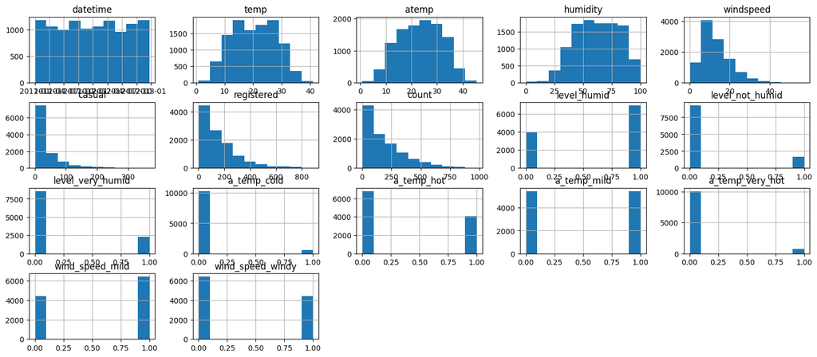

```python
# View histogram of all features again now with the new features
train.hist(figsize=(19,10), layout=(5,5),)
```

## Step 5: Rerun the model with the same settings as before, just with more features

```python
train_data = train.loc[:, ~train.columns.isin(DATA_COLS_TO_IGNORE)]

# Same settings for the model
# data has new features
predictor_new_features = TabularPredictor(
    label=predictor_options["label"],
    eval_metric=predictor_options["eval_metric"]
).fit(
    train_data=train_data,
    time_limit=predictor_options["time_limit"],
    presets=predictor_options["presets"]
)
```

[output not shown]

[output cut: 63 more lines]

```
	-32.5391	 = Validation score   (-root_mean_squared_error)
	11.14s	 = Training   runtime
	0.49s	 = Validation runtime
Fitting model: CatBoost_BAG_L2 ... Training model for up to 2.37s of the 2.36s of remaining time.
	Fitting 8 child models (S1F1 - S1F8) | Fitting with ParallelLocalFoldFittingStrategy
	-66.4968	 = Validation score   (-root_mean_squared_error)
	2.04s	 = Training   runtime
	0.11s	 = Validation runtime
Completed 1/20 k-fold bagging repeats ...
Fitting model: WeightedEnsemble_L3 ... Training model for up to 119.84s of the -4.63s of remaining time.
	-30.1502	 = Validation score   (-root_mean_squared_error)
	0.24s	 = Training   runtime
	0.0s	 = Validation runtime
AutoGluon training complete, total runtime = 124.89s ... Best model: "WeightedEnsemble_L3"
TabularPredictor saved. To load, use: predictor = TabularPredictor.load("AutogluonModels/ag-20230126_221002/")
```

```python
predictor_new_features.fit_summary()
```

```
*** Summary of fit() ***
Estimated performance of each model:
                     model   score_val  pred_time_val   fit_time  pred_time_val_marginal  fit_time_marginal  stack_level  can_infer  fit_order
0      WeightedEnsemble_L3  -30.150182      12.304694  74.709809                0.000583           0.239285            3       True         13
1          LightGBM_BAG_L2  -30.522607      11.139645  67.727525                0.603756           5.692148            2       True         10
2        LightGBMXT_BAG_L2  -30.909528      11.700355  68.778375                1.164466           6.742999            2       True          9
3   RandomForestMSE_BAG_L2  -32.539124      11.029065  73.173609                0.493176          11.138233            2       True         11
4      WeightedEnsemble_L2  -33.559147      10.293886  31.316910                0.000485           0.267402            2       True          8
5        LightGBMXT_BAG_L1  -34.970563       5.608467   8.845168                5.608467           8.845168            1       True          3
6          LightGBM_BAG_L1  -35.427540       3.733744  13.339900                3.733744          13.339900            1       True          4
7   RandomForestMSE_BAG_L1  -38.449993       0.452772   5.285340                0.452772           5.285340            1       True          5
8     ExtraTreesMSE_BAG_L1  -38.589384       0.473804   3.538431                0.473804           3.538431            1       True          7
9          CatBoost_BAG_L1  -41.551836       0.216884  30.956541                0.216884          30.956541            1       True          6
10         CatBoost_BAG_L2  -66.496812      10.648888  64.078831                0.112999           2.043454            2       True         12
11   KNeighborsDist_BAG_L1  -84.125061       0.024614   0.040669                0.024614           0.040669            1       True          2
12   KNeighborsUnif_BAG_L1 -101.546199       0.025604   0.029328                0.025604           0.029328            1       True          1
Number of models trained: 13
Types of models trained:
{'StackerEnsembleModel_RF', 'StackerEnsembleModel_LGB', 'WeightedEnsembleModel', 'StackerEnsembleModel_CatBoost', 'StackerEnsembleModel_KNN', 'StackerEnsembleModel_XT'}
Bagging used: True  (with 8 folds)
Multi-layer stack-ensembling used: True  (with 3 levels)
Feature Metadata (Processed):
(raw dtype, special dtypes):
('category', [])             :  7 | ['season', 'weather', 'hour', 'day', 'month', ...]
('float', [])                :  3 | ['temp', 'atemp', 'windspeed']
('int', [])                  :  1 | ['humidity']
('int', ['bool'])            : 12 | ['holiday', 'workingday', 'level_humid', 'level_not_humid', 'level_very_humid', ...]
('int', ['datetime_as_int']) :  5 | ['datetime', 'datetime.year', 'datetime.month', 'datetime.day', 'datetime.dayofweek']
*** End of fit() summary ***
```

[output not shown]

[output cut: 114 more lines]

[output not shown]

```python
new_predictions = predictor_new_features.predict(test)
new_predictions.head()
new_predictions.info()

# Set negative values to zero
new_predictions[new_predictions < 0] = 0
```

```
<class 'pandas.core.series.Series'>
RangeIndex: 6493 entries, 0 to 6492
Series name: count
Non-Null Count  Dtype
--------------  -----
6493 non-null   float32
dtypes: float32(1)
memory usage: 25.5 KB
```

```python
# Same submitting predictions
submission_new_features = pd.read_csv("sampleSubmission.csv", parse_dates=["datetime"])
submission_new_features["count"] = new_predictions
submission_new_features.to_csv("submission_new_features.csv", index=False)
```

```python
!kaggle competitions submit -c bike-sharing-demand -f submission_new_features.csv -m "New features test #5"
```

```
Successfully submitted to Bike Sharing Demand
```

```python
!kaggle competitions submissions -c bike-sharing-demand | tail -n +1 | head -n 6
```

```
fileName                     date                 description                          status    publicScore  privateScore
---------------------------  -------------------  -----------------------------------  --------  -----------  ------------
submission_new_features.csv  2023-01-26 22:12:22  New features test #5                 complete  0.72621      0.72621
submission.csv               2023-01-26 22:06:20  Raw submission #4                    complete  1.80891      1.80891
submission_new_hpo.csv       2023-01-26 21:47:34  new features hpo iii                 complete  0.48829      0.48829
submission_new_features.csv  2023-01-26 21:45:16  new features test iv                 complete  0.71067      0.71067
```

#### New Score of `0.72621`

## Step 6: Hyper parameter optimization

- There are many options for hyper parameter optimization.
- Options are to change the AutoGluon higher level parameters or the individual model hyperparameters.
- The hyperparameters of the models themselves that are in AutoGluon. Those need the `hyperparameter` and `hyperparameter_tune_kwargs` arguments.

```python
import autogluon.core as ag


train_data = train.loc[:, ~train.columns.isin(DATA_COLS_TO_IGNORE)]


# specifies non-default hyperparameter values for neural network models
nn_options = {
     # number of training epochs (controls training time of NN models)
    'num_epochs': 70,

     # learning rate used in training (real-valued hyperparameter searched on log-scale)
    'learning_rate': ag.space.Real(0.0001, 0.001, default=0.0005, log=True),

     # activation function used in NN (categorical hyperparameter, default = first entry)
    'activation': ag.space.Categorical('relu', 'softrelu', 'tanh'),

     # dropout probability (real-valued hyperparameter)
    'dropout_prob': ag.space.Real(0.0, 0.5, default=0.1),
}

# specifies non-default hyperparameter values for lightGBM gradient boosted trees
gbm_options = {
     # number of boosting rounds (controls training time of GBM models)
    'num_boost_round': 1000,

     # number of leaves in trees (integer hyperparameter)
    'num_leaves': ag.space.Int(lower=26, upper=99, default=36),

     # learning rate used in training (real-valued hyperparameter searched on log-scale)
    'learning_rate': ag.space.Real(0.0001, 0.1, log=True),
}

# specifies non-default hyperparameter values for XGB gradient boosted trees
xgb_options = {
     # number of boosting rounds (controls training time of GBM models)
    'n_estimators': 1000,

     # learning rate used in training (real-valued hyperparameter searched on log-scale)
    'learning_rate': ag.space.Real(0.0001, 0.1, log=True),
}


# hyperparameters of each model type
hyperparameters = {
    'NN_TORCH': nn_options,
    'GBM': gbm_options,
    'XGB': xgb_options,
    "RF": {},
}

time_limit = 3*60  # train various models for ~3 min
num_trials = 5  # try at most 5 different hyperparameter configurations for each type of model
search_strategy = 'auto'  # to tune hyperparameters using random search routine with a local scheduler

# HPO is not performed unless hyperparameter_tune_kwargs is specified
hyperparameter_tune_kwargs = {
    'num_trials': num_trials,
    'scheduler' : 'local',
    'searcher': search_strategy,
}

predictor_new_hpo = TabularPredictor(
    label=predictor_options["label"],
    eval_metric=predictor_options["eval_metric"],
).fit(
    auto_stack=True,
    train_data=train_data,
    time_limit=predictor_options["time_limit"],
    presets=predictor_options["presets"],
    hyperparameters=hyperparameters,
    hyperparameter_tune_kwargs=hyperparameter_tune_kwargs,
)
```

```
No model was trained during hyperparameter tuning NeuralNetTorch_BAG_L2... Skipping this model.
Completed 1/20 k-fold bagging repeats ...
Fitting model: WeightedEnsemble_L3 ... Training model for up to 119.83s of the 4.49s of remaining time.
	-39.411	 = Validation score   (-root_mean_squared_error)
	0.18s	 = Training   runtime
	0.0s	 = Validation runtime
AutoGluon training complete, total runtime = 115.72s ... Best model: "WeightedEnsemble_L2"
TabularPredictor saved. To load, use: predictor = TabularPredictor.load("AutogluonModels/ag-20230126_221224/")
```

```python
predictor_new_hpo.fit_summary()
```

```
*** Summary of fit() ***
Estimated performance of each model:
                 model   score_val  pred_time_val   fit_time  pred_time_val_marginal  fit_time_marginal  stack_level  can_infer  fit_order
0  RandomForest_BAG_L1  -38.449993       0.000126   8.213018                0.000126           8.213018            1       True          2
1  WeightedEnsemble_L2  -38.449993       0.000715   8.423260                0.000588           0.210242            2       True          4
2  RandomForest_BAG_L2  -39.410987       0.000602  49.380072                0.000120           9.562921            2       True          6
3  WeightedEnsemble_L3  -39.410987       0.001269  49.557634                0.000667           0.177562            3       True          8
4   LightGBM_BAG_L2/T1 -164.759156       0.000651  54.720999                0.000168          14.903848            2       True          5
5   LightGBM_BAG_L1/T1 -166.785064       0.000237  12.258525                0.000237          12.258525            1       True          1
6    XGBoost_BAG_L1/T1 -254.008124       0.000119  19.345608                0.000119          19.345608            1       True          3
7    XGBoost_BAG_L2/T1 -254.258671       0.000620  54.919493                0.000138          15.102342            2       True          7
Number of models trained: 8
Types of models trained:
{'StackerEnsembleModel_LGB', 'WeightedEnsembleModel', 'StackerEnsembleModel_XGBoost', 'StackerEnsembleModel_RF'}
Bagging used: True  (with 8 folds)
Multi-layer stack-ensembling used: True  (with 3 levels)
Feature Metadata (Processed):
(raw dtype, special dtypes):
('category', [])             :  7 | ['season', 'weather', 'hour', 'day', 'month', ...]
('float', [])                :  3 | ['temp', 'atemp', 'windspeed']
('int', [])                  :  1 | ['humidity']
('int', ['bool'])            : 12 | ['holiday', 'workingday', 'level_humid', 'level_not_humid', 'level_very_humid', ...]
('int', ['datetime_as_int']) :  5 | ['datetime', 'datetime.year', 'datetime.month', 'datetime.day', 'datetime.dayofweek']
*** End of fit() summary ***
```

[output not shown]

[output cut: 51 more lines]

[output not shown]

```python
new_hop_predictions = predictor_new_hpo.predict(test)
new_hop_predictions.head()
new_hop_predictions.info()

# Set negative values to zero
new_hop_predictions[new_hop_predictions < 0] = 0
```

```
<class 'pandas.core.series.Series'>
RangeIndex: 6493 entries, 0 to 6492
Series name: count
Non-Null Count  Dtype
--------------  -----
6493 non-null   float32
dtypes: float32(1)
memory usage: 25.5 KB
```

```python
# Same submitting predictions
submission_new_hpo = pd.read_csv("sampleSubmission.csv", parse_dates=["datetime"])
submission_new_hpo["count"] = new_hop_predictions
submission_new_hpo.to_csv("submission_new_hpo.csv", index=False)
```

```python
!kaggle competitions submit -c bike-sharing-demand -f submission_new_hpo.csv -m "New features hpo #4"
```

```
Successfully submitted to Bike Sharing Demand
```

```python
!kaggle competitions submissions -c bike-sharing-demand | tail -n +1 | head -n 5
```

```
fileName                     date                 description                          status    publicScore  privateScore
---------------------------  -------------------  -----------------------------------  --------  -----------  ------------
submission_new_hpo.csv       2023-01-26 22:14:28  New features hpo #4                  complete  0.48829      0.48829
submission_new_features.csv  2023-01-26 22:12:22  New features test #5                 complete  0.72621      0.72621
submission.csv               2023-01-26 22:06:20  Raw submission #4                    complete  1.80891      1.80891
```

#### New Score of `0.48829`

## Step 7: Write a Report

### Refer to the markdown file for the full report

### Creating plots and table for report

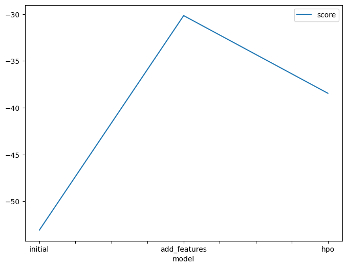

```python
# Taking the top model score from each training run and creating a line plot to show improvement
# You can create these in the notebook and save them to PNG or use some other tool (e.g. google sheets, excel)
fig = pd.DataFrame({
    "model": ["initial", "add_features", "hpo"],
    "score": [-53.062678, -30.150182, -38.449993]
}).plot(
    x="model",
    y="score",
    figsize=(8, 6)
).get_figure()

fig.savefig('model_train_score.png')
```

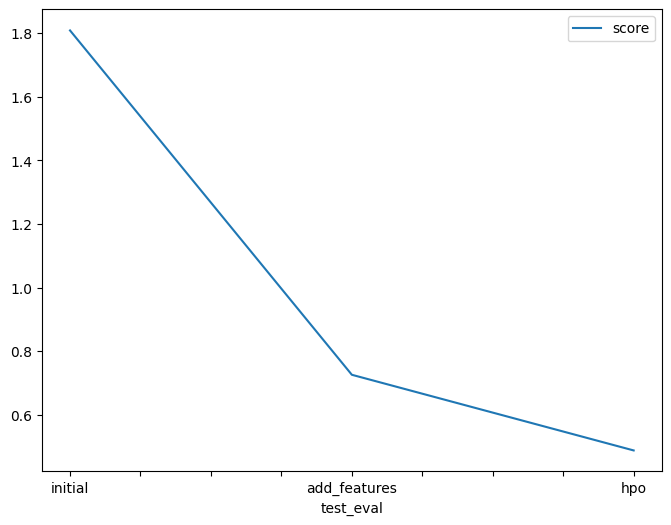

```python
# Take the 3 kaggle scores and creating a line plot to show improvement
fig = pd.DataFrame({
    "test_eval": ["initial", "add_features", "hpo"],
    "score": [1.80891, 0.72621, 0.48829]
}).plot(
    x="test_eval",
    y="score",
    figsize=(8, 6)
).get_figure()

fig.savefig('model_test_score.png')
```

### Hyperparameter table

```python
# The 3 hyperparameters we tuned with the kaggle score as the result
pd.DataFrame({
    "model": ["initial", "add_features", "hpo"],
    "hpo1": [{}, {}, {  #hpo1 => NN_TORCH
                        'num_epochs': 70,
                        'learning_rate': ag.space.Real(0.0001, 0.001, default=0.0005, log=True),
                        'activation': ag.space.Categorical('relu', 'softrelu', 'tanh'),
                        'dropout_prob': ag.space.Real(0.0, 0.5, default=0.1),
                     }
            ],
    "hpo2": [{}, {}, {  #hpo2 => GBM
                        'num_boost_round': 1000,
                        'num_leaves': ag.space.Int(lower=26, upper=99, default=36),
                        'learning_rate': ag.space.Real(0.0001, 0.1, log=True),
                     }
            ],
    "hpo3": [{}, {}, {  #hpo3 => XGB
                        'n_estimators': 1000,
                        'learning_rate': ag.space.Real(0.0001, 0.1, log=True),
                      }
            ],
    "score": [1.80891, 0.72621, 0.48829]
})
```

|  | model | hpo1 | hpo2 | hpo3 | score |
| --- | --- | --- | --- | --- | --- |
| 0 | initial | {} | {} | {} | 1.80891 |
| 1 | add_features | {} | {} | {} | 0.72621 |
| 2 | hpo | {'num_epochs': 70, 'learning_rate': Real: lowe... | {'num_boost_round': 1000, 'num_leaves': Int: l... | {'n_estimators': 1000, 'learning_rate': Real: ... | 0.48829 |